# Prácticas de Estadística Ejercicio de la Práctica 2 Variable Aleatoria

Juan Luis Herreros Bódalo

Versión 22-diciembre-2020

# Primer ejercicio

Consideremos una variable aleatoria, $X$ que sigue una distribución $B(15, 0.33)$. Se pide:

1. Calcular:
- $P[4\leq X \leq 8]$.

```r
# Responde aquí
sum(dbinom(4:8,15,0.33))
```

```
## [1] 0.7540009
```

- $P[4 < X \leq 8]$.

```r
# Responde aquí
sum(dbinom(5:8,15,0.33))
```

```
## [1] 0.5562988
```

- $P[4 < X < 8]$.

```r
# Responde aquí
sum(dbinom(5:7,15,0.33))
```

```
## [1] 0.5014479
```

- $P[X \geq 4]$.

```r
# Responde aquí
sum(dbinom(4:15,15,0.33))
```

```
## [1] 0.7828694
```

- $P[X > 4]$.

```r
# Responde aquí
sum(dbinom(5:15,15,0.33))
```

```
## [1] 0.5851673
```

2. Obtener:
- El primer valor de la variable que deja por debajo de sí al menos el 95% de la probabilidad:

```r
# Responde aquí
qbinom(0.95,15,0.33)
```

```
## [1] 8
```

- El percentil 95 de la distribución.

```r
# Responde aquí
qbinom(0.95,15,0.33)
```

```
## [1] 8
```

3. Obtener una muestra de tamaño 10 de esta distribución

```r
# Responde aquí
rbinom(10,15,0.33)
```

```
##  [1] 10  6  7  3  8  4  5  4  5  6
```

# Segundo ejercicio

Consideremos una variable aleatoria que sigue una distribución $Poisson(7.2)$. Se pide:

1. Calcular:
- $P[X > 5]$.

```r
# Responde aquí
1-sum(dpois(0:5,7.2))
```

```
## [1] 0.7241025
```

- $P[X \geq 5]$.

```r
# Responde aquí
1-sum(dpois(0:4,7.2))
```

```
## [1] 0.8444844
```

- $P[2 < X < 8]$.

```r
# Responde aquí
sum(dpois(3:7,7.2))
```

```
## [1] 0.5434677
```

- $P[2 \leq X < 8]$.

```r
# Responde aquí
sum(dpois(2:7,7.2))
```

```
## [1] 0.5628192
```

- $P[2 < X \leq 8]$.

```r
# Responde aquí
sum(dpois(3:8,7.2))
```

```
## [1] 0.6771948
```

- $P[X < 7]$.

```r
# Responde aquí
sum(dpois(0:6,7.2))
```

```
## [1] 0.4203557
```

- $P[X \leq 7]$.

```r
# Responde aquí
sum(dpois(0:7,7.2))
```

```
## [1] 0.5689412
```

- $P[X = 7]$.

```r
# Responde aquí
sum(dpois(7,7.2))
```

```
## [1] 0.1485856
```

2. Obtener:
- El percentil 75 de la distribución.

```r
# Responde aquí
qpois(0.75,7.2)
```

```
## [1] 9
```

- El primer valor de la variable que deja por debajo de sí al menos el 5% de sus valores.

```r
# Responde aquí
qpois(0.05,7.2)
```

```
## [1] 3
```

3. Obtener una muestra de tamaño 5 de la distribución.

```r
# Responde aquí
rpois(5,7.2)
```

```
## [1]  8  6 11  6  5
```

# Tercer ejercicio

Consideremos una variable aleatoria $X$ que sigue una distribución exponencial **de media 2**. Se pide:

1. Calcular:
- $P [X = 5]$.

```r
# Responde aquí
pexp(5,1/2)-pexp(5,1/2)
```

```
## [1] 0
```

- $P [X \leq 5]$.

```r
# Responde aquí
pexp(5,1/2)
```

```
## [1] 0.917915
```

- $P [X < 5]$.

```r
# Responde aquí
pexp(5,1/2)
```

```
## [1] 0.917915
```

- $P [2 \leq X \leq 8]$.

```r
# Responde aquí
pexp(8,1/2)-pexp(2,1/2)
```

```
## [1] 0.3495638
```

- $P [2 < X \leq 8]$.

```r
# Responde aquí
pexp(8,1/2)-pexp(2,1/2)
```

```
## [1] 0.3495638
```

- $P [2 \leq X < 8]$.

```r
# Responde aquí
pexp(8,1/2)-pexp(2,1/2)
```

```
## [1] 0.3495638
```

2. Obtener:
- El percentil 5 y el percentil 95.

```r
# Responde aquí
qexp(c(0.05,0.95),1/2)
```

```
## [1] 0.1025866 5.9914645
```

- El valor de la variable que deja por debajo de sí el 30% del resto de valores de la variable.

```r
# Responde aquí
qexp(0.3,1/2)
```

```
## [1] 0.7133499
```

- El valor de la variable que deja por encima de sí el 70% del resto de valores de la variable.

```r
# Responde aquí
qexp(0.3,1/2)
```

```
## [1] 0.7133499
```

3. Obtener una muestra de tamaño 10 de la distribución.

```r
# Responde aquí
rexp(10,1/2)
```

```
##  [1] 7.84232807 0.53183640 1.29795978 0.84039663 1.06636372 2.72657756
##  [7] 0.04059388 0.71413971 4.34875244 2.09762938
```

4. Representar:
- La probabilidad $P [2 \leq X \leq 8]$ como área bajo la función de densidad.

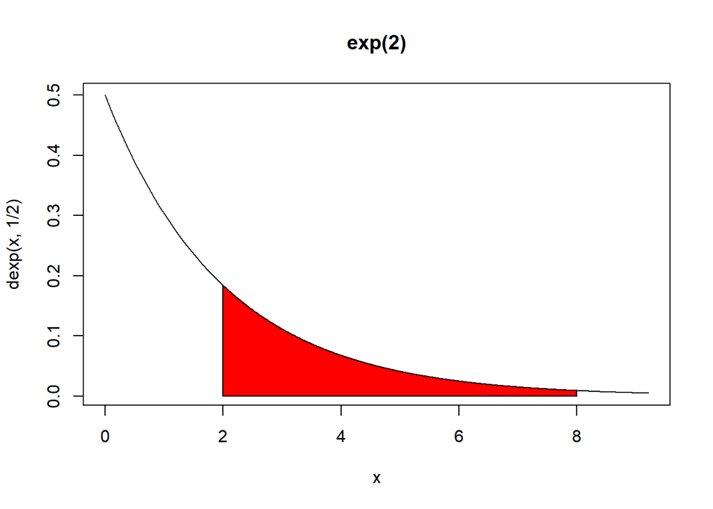

```r
# Responde aquí
# Primero representamos lo que estamos calculando
a <- 2 # Extremo inferior
b <- 8 # Extremo superior
cord.x <- c(a, seq(a, b, 0.01), b)
cord.y <- c(0, dexp(seq(a, b, 0.01), 1/2), 0)
curve(dexp(x, 1/2), xlim = c(0, qexp(0.99, 1/2)), main = 'exp(2)')
polygon(cord.x, cord.y, col = 'red')
```

- La probabilidad $P [X \leq 8]$ como área bajo la función de densidad.

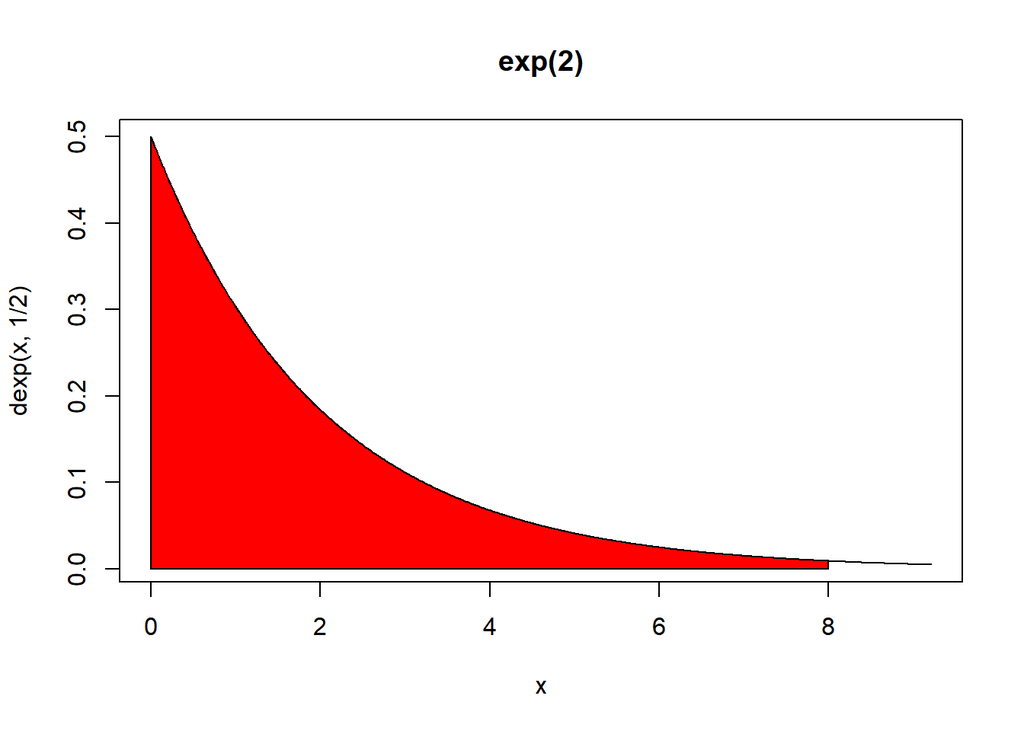

```r
# Responde aquí
# Primero representamos lo que estamos calculando
a <- 0 # Extremo inferior
b <- 8 # Extremo superior
cord.x <- c(a, seq(a, b, 0.01), b)
cord.y <- c(0, dexp(seq(a, b, 0.01), 1/2), 0)
curve(dexp(x, 1/2), xlim = c(0, qexp(0.99, 1/2)), main = 'exp(2)')
polygon(cord.x, cord.y, col = 'red')
```

- La probabilidad $P [X > 2]$ como área bajo la función de densidad.

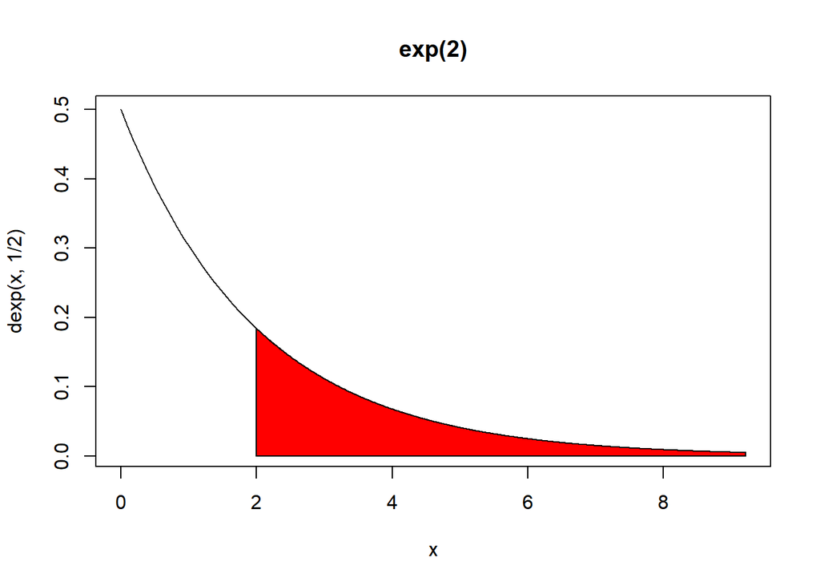

```r
# Responde aquí
# Primero representamos lo que estamos calculando
a <- 2 # Extremo inferior
b <- qexp(0.99, 1/2) # Extremo superior
cord.x <- c(a, seq(a, b, 0.01), b)
cord.y <- c(0, dexp(seq(a, b, 0.01), 1/2), 0)
curve(dexp(x, 1/2), xlim = c(0, qexp(0.99, 1/2)), main = 'exp(2)')
polygon(cord.x, cord.y, col = 'red')
```

- La probabilidad $P [X = 2]$ como área bajo la función de densidad.

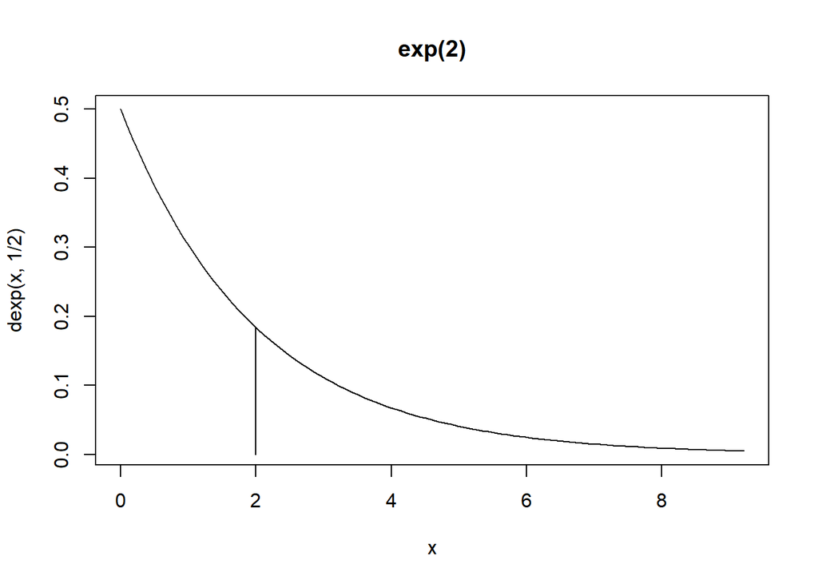

```r
# Responde aquí
a <- 2 # Extremo inferior
b <- 2 # Extremo superior (obviamente no ponemos infinito, sino un valor alto de la distribución)
cord.x <- c(a, seq(a, b, 0.01), b)
cord.y <- c(0, dexp(seq(a, b, 0.01), 1/2), 0)
curve(dexp(x, 1/2), xlim = c(0, qexp(0.99, 1/2)), main = 'exp(2)')
polygon(cord.x, cord.y, col = 'red')
```

# Cuarto ejercicio

Consideremos una variable aleatoria $W$ con distribución $Normal(250, 13)$. Se pide:

1. Calcular:
- $P[240 \leq W < 250]$.

```r
# Responde aquí
pnorm(250,250,13)-pnorm(240,250,13)
```

```
## [1] 0.2791218
```

- $P[240 < W \leq 250]$.

```r
# Responde aquí
pnorm(250,250,13)-pnorm(240,250,13)
```

```
## [1] 0.2791218
```

- $P [W > 271]$.

```r
# Responde aquí
1-pnorm(271,250,13)
```

```
## [1] 0.05311371
```

- $P [W < 271]$.

```r
# Responde aquí
pnorm(271,250,13)
```

```
## [1] 0.9468863
```

- $P [W = 271]$.

```r
# Responde aquí
pnorm(271,250,13)-pnorm(271,250,13)
```

```
## [1] 0
```

2. Obtener:
- El intervalo de valores de la variable que excluye el 5% de los valores más altos de la distribución y el 5% de valores más bajos.

```r
# Responde aquí
qnorm(c(0.95,0.05),250,13)
```

```
## [1] 271.3831 228.6169
```

3. Obtener una muestra de tamaño 10 de la distribución.

```r
# Responde aquí
rnorm(10,250,13)
```

```
##  [1] 245.3537 255.9068 250.0730 255.6941 246.1896 250.7884 246.2174 246.8220
##  [9] 258.7409 252.7859
```

4. Representar:
- La probabilidad $P [W > 271]$ como área bajo la función de densidad.

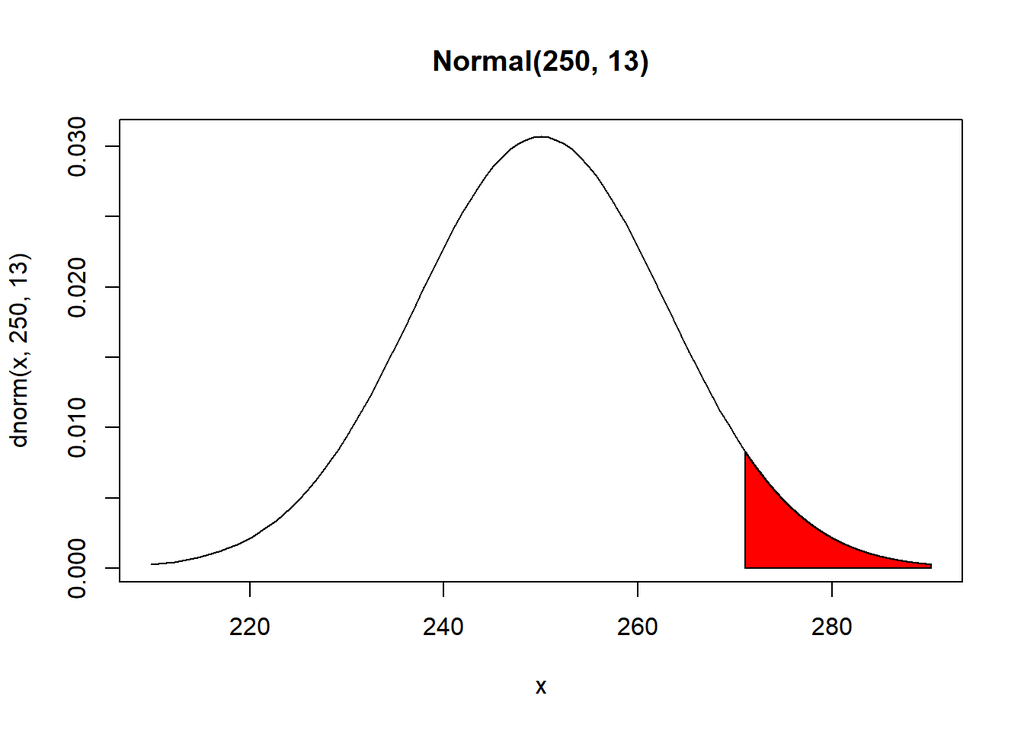

```r
# Responde aquí
# Primero representamos lo que estamos calculando
a <- 271 # Extremo inferior
b <- qnorm(0.999, 250,13) # Extremo superior (obviamente no ponemos infinito, sino un valor alto de la distribución)
cord.x <- c(a, seq(a, b, 0.01), b)
cord.y <- c(0, dnorm(seq(a, b, 0.01), 250,13), 0)
curve(dnorm(x, 250,13), xlim = qnorm(c(0.001, 0.999),250,13), main = 'Normal(250, 13)')
polygon(cord.x, cord.y, col = 'red')
```

- La probabilidad $P [W < 271]$ como área bajo la función de densidad.

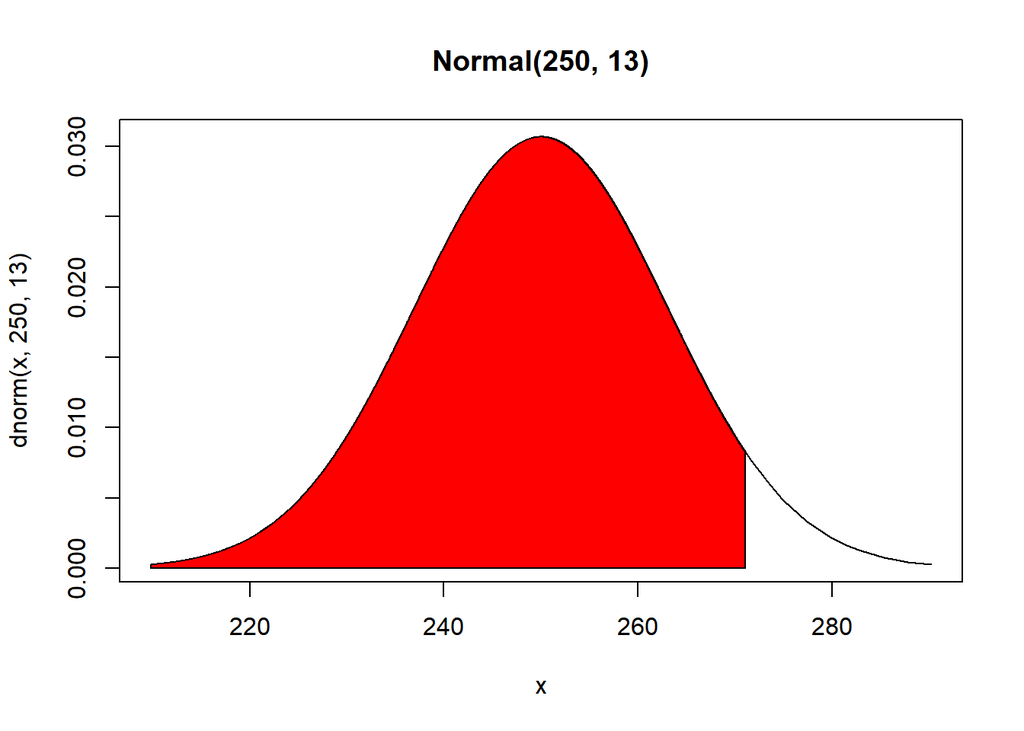

```r
# Responde aquí
# Primero representamos lo que estamos calculando
a <- qnorm(0.001, 250,13) # Extremo inferior
b <- 271 # Extremo superior (obviamente no ponemos infinito, sino un valor alto de la distribución)
cord.x <- c(a, seq(a, b, 0.01), b)
cord.y <- c(0, dnorm(seq(a, b, 0.01), 250,13), 0)
curve(dnorm(x, 250,13), xlim = qnorm(c(0.001, 0.999),250,13), main = 'Normal(250, 13)')
polygon(cord.x, cord.y, col = 'red')
```

- La probabilidad $P [W \leq 271]$ como área bajo la función de densidad.

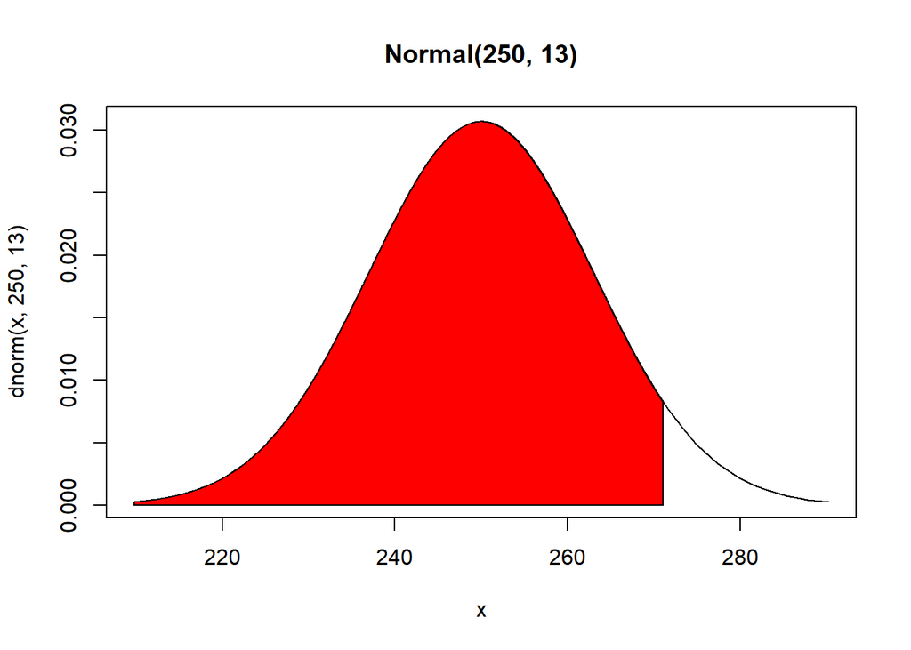

```r
# Responde aquí
# Primero representamos lo que estamos calculando
a <- qnorm(0.001, 250,13) # Extremo inferior
b <- 271 # Extremo superior (obviamente no ponemos infinito, sino un valor alto de la distribución)
cord.x <- c(a, seq(a, b, 0.01), b)
cord.y <- c(0, dnorm(seq(a, b, 0.01), 250,13), 0)
curve(dnorm(x, 250,13), xlim = qnorm(c(0.001, 0.999),250,13), main = 'Normal(250, 13)')
polygon(cord.x, cord.y, col = 'red')
```

- La probabilidad $P [W = 271]$ como área bajo la función de densidad.

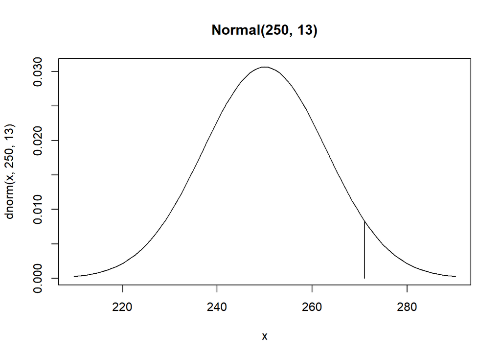

```r
# Responde aquí
# Primero representamos lo que estamos calculando
a <- 271 # Extremo inferior
b <- 271 # Extremo superior (obviamente no ponemos infinito, sino un valor alto de la distribución)
cord.x <- c(a, seq(a, b, 0.01), b)
cord.y <- c(0, dnorm(seq(a, b, 0.01), 250,13), 0)
curve(dnorm(x, 250,13), xlim = qnorm(c(0.001, 0.999),250,13), main = 'Normal(250, 13)')
polygon(cord.x, cord.y, col = 'red')
```